# STAT420 Homework 1

Alok K. Shukla

8/28/2016

# Assignment Solutions

## Exercise 1 (Working with Vectors)

The given vector of data.

```r
x = c(1, 1, 2, 3, 5, 8, 13, 21, 34, 55, 89, 144)
```

**(a)** Calculation of the sample mean of `x` *without* the use of `mean()`, `sd()`, `sum()`, or `+`.

**Solution** Using the matrix multiplication operator `%*%`

If we multiply a row vector with a unit column vector of conformable size, we will essentially get sum of elements in row vector.

1. Create a row matrix of `x` using Transpose function `t` on Matrix function `matrix`

```r
x_rowmatrix = t(matrix(x))
x_rowmatrix
```

```
##      [,1] [,2] [,3] [,4] [,5] [,6] [,7] [,8] [,9] [,10] [,11] [,12]
## [1,]    1    1    2    3    5    8   13   21   34    55    89   144
```

2. Create a unit vector of conformable size

```r
unit_vector = rep(1, times = length(x))
unit_vector
```

```
##  [1] 1 1 1 1 1 1 1 1 1 1 1 1
```

3. Multiply both and get the value of total using `as.numeric`

```r
total = as.numeric(x_rowmatrix %*% unit_vector)
total
```

```
## [1] 376
```

Note: This works even when the second argument is a vector. Help doc for `%*%` says *“If one argument is a vector, it will be promoted to either a row or column matrix to make the two arguments conformable”*

4. Get the mean

```r
computed_mean = total/length(x)
computed_mean
```

```
## [1] 31.33333
```

5. The mean computed with `mean`

```r
mean(x)
```

```
## [1] 31.33333
```

**(b)** Calculate the sample standard deviation of `x` *without* the use of `mean()`, `sd()`, `sum()`, or `+`.

**Solution**

If we take the mod of cross product of a vector with itself we essentially get the sum of squares of the elements in the vector. By definition SD is sqaure root of average sum of residual ( actual value $-$ mean).

1. Create the residual vector

```r
x_residuals = x - computed_mean
x_residuals
```

```
##  [1] -30.333333 -30.333333 -29.333333 -28.333333 -26.333333 -23.333333
##  [7] -18.333333 -10.333333   2.666667  23.666667  57.666667 112.666667
```

2. Compute sum of squares

```r
ssq_x = as.numeric(crossprod(x_residuals))
ssq_x
```

```
## [1] 21770.67
```

3. Compute average and square root

```r
computed_sd = sqrt(ssq_x/(length(x)-1))
computed_sd
```

```
## [1] 44.48766
```

4. Compare with actual sd

```r
sd(x)
```

```
## [1] 44.48766
```

## Exercise 2 (Vectors and Matrices)

**(a)** Create five vectors `x0`, `x1`, `x2`, `x3`, and `y`. Each should have a length of 30 and store the following:

- `x0`: Each element should be the value `1`.

**Solution**

```r
x0 = rep(1,30)
x0
```

```
##  [1] 1 1 1 1 1 1 1 1 1 1 1 1 1 1 1 1 1 1 1 1 1 1 1 1 1 1 1 1 1 1
```

- `x1`: The first 30 square numbers.

**Solution**

```r
x1 = (seq(1,30,1))^2
x1
```

```
##  [1]   1   4   9  16  25  36  49  64  81 100 121 144 169 196 225 256 289
## [18] 324 361 400 441 484 529 576 625 676 729 784 841 900
```

```r
length(x1)
```

```
## [1] 30
```

- `x2`: 30 evenly spaced numbers between `0` and `1`.

**Solution**

```r
x2 = (seq(0,1,(1/29)))
x2
```

```
##  [1] 0.00000000 0.03448276 0.06896552 0.10344828 0.13793103 0.17241379
##  [7] 0.20689655 0.24137931 0.27586207 0.31034483 0.34482759 0.37931034
## [13] 0.41379310 0.44827586 0.48275862 0.51724138 0.55172414 0.58620690
## [19] 0.62068966 0.65517241 0.68965517 0.72413793 0.75862069 0.79310345
## [25] 0.82758621 0.86206897 0.89655172 0.93103448 0.96551724 1.00000000
```

```r
length(x2)
```

```
## [1] 30
```

*Note*: taking increment $1/30$ would generate 31 numbers in total.

- `x3`: The natural log of the integers from `1` to `30`.

**Solution**

```r
x3 = log(seq(1,30,1))
x3
```

```
##  [1] 0.0000000 0.6931472 1.0986123 1.3862944 1.6094379 1.7917595 1.9459101
##  [8] 2.0794415 2.1972246 2.3025851 2.3978953 2.4849066 2.5649494 2.6390573
## [15] 2.7080502 2.7725887 2.8332133 2.8903718 2.9444390 2.9957323 3.0445224
## [22] 3.0910425 3.1354942 3.1780538 3.2188758 3.2580965 3.2958369 3.3322045
## [29] 3.3672958 3.4011974
```

- `y`: The result of running the following code, after creating the other four vectors:

```r
set.seed(42)
y  = 5 * x0 + 1 * x1 + 6 * x2 + 3 * x3 + rnorm(n = 30, mean = 0 , sd = 1)
```

Report the value returned from `sum(y)`.

**Solution**

```r
sum(y)
```

```
## [1] 9921.032
```

**(b)** Create a matrix `X` which stores `x0`, `x1`, `x2`, and `x3` as columns of the matrix. Report the value returned from `sum(X)`.

**Solution**

```r
X = cbind(x0,x1,x2,x3)
sum(X)
```

```
## [1] 9574.658
```

**(c)** Use matrix operations to create a new matrix `beta_hat` defined as follows:

$$\hat{\beta} = (X^T X)^{-1} X^T y.$$

Report the values stored in the matrix `beta_hat`. Note that you can use the vector `y` as if it is a $30 \times 1$ matrix.

**Solution**

```r
beta_hat = (solve(t(X)%*%X))%*%(t(X)%*%y)
beta_hat
```

```
##          [,1]
## x0 5.46958062
## x1 1.00368479
## x2 0.06676534
## x3 3.56429107
```

**(d)** Subset `beta_hat` matrix to exclude the first row, then square each element and report the sum of these results.

**Solution**

```r
beta_hat_subset_squaresum = as.numeric(crossprod(beta_hat[2:4,]))
beta_hat_subset_squaresum
```

```
## [1] 13.71601
```

As mentioned earlier, `crossprod` can be used to calcualte sum of element sqaures of any vector.

**(e)** Create a new variable `y_hat` which stores the result of the matrix operation,

$$\hat{y} = X \hat{\beta}.$$

Perform and report the result of the following operation,

$$\sum_{i = 1}^{30} (y_i - \hat{y}_i)^ 2.$$

**Solution**

```r
y_hat = X%*%beta_hat
residual_y = y-y_hat
ssq_y = as.numeric(crossprod(residual_y))
ssq_y
```

```
## [1] 41.56007
```

## Exercise 3 (Discrete Probability)

The [2016 United States presidential election](https://en.wikipedia.org/wiki/United_States_presidential_election,_2016) has been an interesting contest. A [Fox News National Poll](http://www.foxnews.com/politics/interactive/2016/06/09/fox-news-poll-national-releas-6-16/) from June which surveyed 1004 registered voters placed former New Mexico Governor [Gary Johnson](https://en.wikipedia.org/wiki/Gary_Johnson) in third place, which is expected, however polling in the double digits at 12%. ([Third party candidates haven’t performed well in recent years. The last time a third party managed to get votes in the Electoral College was 1968.](https://en.wikipedia.org/wiki/United_States_presidential_election,_1968))

Suppose the true proportion of registered voters that support Johnson is 12% and we obtain our own random sample of 50 registered voters. Answer the follows questions as they relate to this sample of 50 voters.

**(a)** What is the probability that exactly 5 of the voters are Johnson supporters?

**Solution**

```r
dbinom(5,size=50,prob=0.12)
```

```
## [1] 0.1673818
```

**(b)** What is the probability that 10 or fewer voters are Johnson supporters?

**Solution**

```r
pbinom(10,size=50,prob=0.12,lower.tail = TRUE)
```

```
## [1] 0.967502
```

**(c)** What is the probability that 37 or more voters are **not** Johnson supporters?

**Solution**

```r
install.packages("Rmpfr")
```

```r
require(Rmpfr)
one = mpfr(1,120)
prob = mpfr(pbinom(37,size=50,prob=0.12,lower.tail = FALSE),120)
one - prob
```

```
## 1 'mpfr' number of precision  120   bits
## [1] 0.99999999999999999999999972111520573105
```

*Note*: Used `Rmpfr` package for better precision than default **R**. Otherwise the probability would have been $1$.

**(d)** What is the probability that between 3 and 9 (inclusive) voters are Johnson supporters?

**Solution**

```r
numbers = seq(3,9)
prob = dbinom(numbers,size=50,prob=0.12,log=FALSE)
sum(prob)
```

```
## [1] 0.8779742
```

## Exercise 4 (Continuous Probability)

For this exercise, consider a random variable $X$ which is normally distributed with a mean of 120 and a standard deviation of 15. That is,

$$X \sim N\left(\mu = 120, \sigma^2 = 225\right).$$

**(a)** Calculate $P(X < 95)$.

**Solution**

```r
pnorm(95,mean=120,sd=15,lower.tail = TRUE,log.p=FALSE)
```

```
## [1] 0.04779035
```

**(b)** Calculate $P(X > 140)$.

**Solution**

```r
pnorm(140,mean=120,sd=15,lower.tail = FALSE,log.p=FALSE)
```

```
## [1] 0.09121122
```

**(c)** Calculate $P(95 < X < 120)$.

**Solution**

```r
pnorm(120,mean=120,sd=15,lower.tail = TRUE,log.p=FALSE) - pnorm(95,mean=120,sd=15,lower.tail = TRUE,log.p=FALSE)
```

```
## [1] 0.4522096
```

**(d)** Find $q$ such that $P(X < q) = 0.05$.

**Solution**

```r
qnorm(0.05,mean=120,sd=15,lower.tail = TRUE,log.p=FALSE)
```

```
## [1] 95.3272
```

**(e)** Find $q$ such that $P(X > q) = 0.10$.

**Solution**

```r
qnorm(0.10,mean=120,sd=15,lower.tail = FALSE,log.p=FALSE)
```

```
## [1] 139.2233
```

## Exercise 5 (Packages, Plotting)

For this exercise, we will use the `diabetes` dataset from the `faraway` package.

**(a)** Install and load the `faraway` package.

**Solution**

```r
library(faraway)
```

**(b)** How many observations are in this dataset? How many variables?

**Solution**

```r
obs = nrow(diabetes)
obs
```

```
## [1] 403
```

```r
cols = ncol(diabetes)
cols
```

```
## [1] 19
```

**(c)** What are the names of the variables in this dataset?

**Solution**

```r
colnames(diabetes)
```

```
##  [1] "id"       "chol"     "stab.glu" "hdl"      "ratio"    "glyhb"
##  [7] "location" "age"      "gender"   "height"   "weight"   "frame"
## [13] "bp.1s"    "bp.1d"    "bp.2s"    "bp.2d"    "waist"    "hip"
## [19] "time.ppn"
```

**(d)** What is the mean [HDL](https://en.wikipedia.org/wiki/High-density_lipoprotein) level (High Density Lipoprotein) of individuals in this sample?

**Solution**

```r
mean(diabetes$hdl,na.rm=TRUE)
```

```
## [1] 50.44527
```

**(e)** What is the standard deviation total cholesterol of individuals in this sample?

**Solution**

```r
sd(diabetes$chol,na.rm=TRUE)
```

```
## [1] 44.44556
```

**(f)** What is the range of ages of individuals in this sample?

**Solution**

```r
range(diabetes$age)
```

```
## [1] 19 92
```

**(g)** What is the mean HDL of females in this sample?

**Solution**

```r
females = subset(diabetes,gender=="female")
mean(females$hdl,na.rm=TRUE)
```

```
## [1] 52.11111
```

**(h)** Create a scatterplot of HDL (y-axis) vs weight (x-axis). Use a non-default color for the points. (Also, be sure to give the plot a title and label the axes appropriately.) Based on the scatterplot, does there seem to be a relationship between the two variables? Briefly explain.

**Solution**

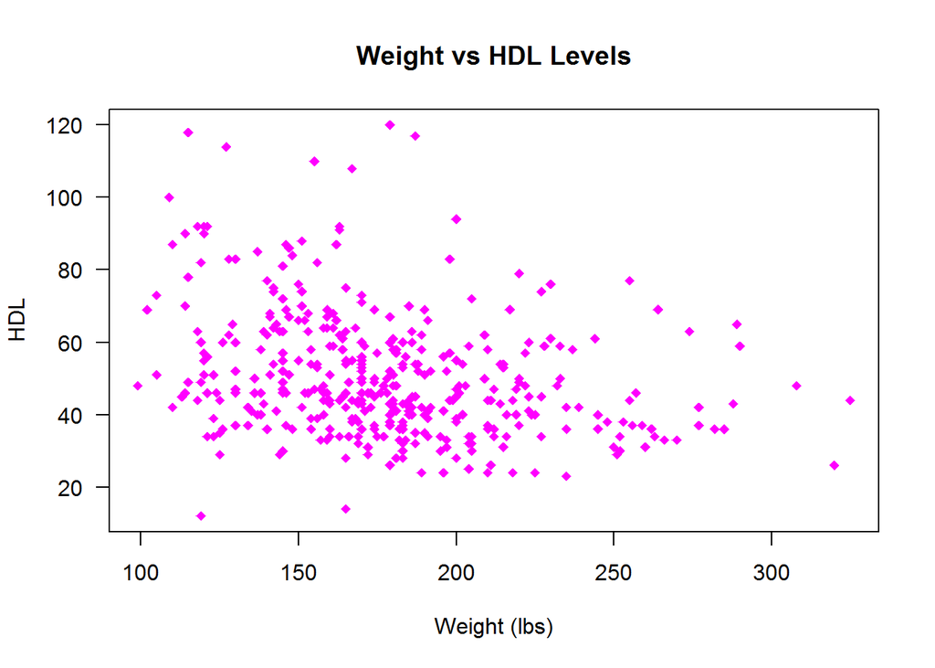

```r
par(las=1)
plot(diabetes$weight, diabetes$hdl, xlab="Weight (lbs)", ylab="HDL",main="Weight vs HDL Levels",col="magenta",pch=18)
```

From scatterplot we can see that there is a slight negative correlation between weight and HDL levels i.e. as weight increases, HDL levels decrease.

```r
cor(diabetes$hdl,diabetes$weight, use="complete")
```

```
## [1] -0.2909825
```

*Note*: `use="complete"` to deal with `NA`

**(i)** Create a scatterplot of total cholesterol (y-axis) vs weight (x-axis). Use a non-default color for the points. (Also, be sure to give the plot a title and label the axes appropriately.) Based on the scatterplot, does there seem to be a relationship between the two variables? Briefly explain.

**Solution**

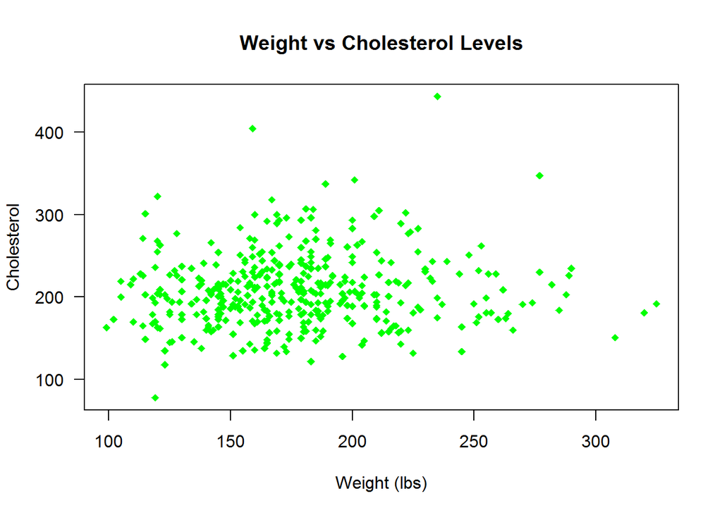

```r
par(las=1)
plot(diabetes$weight, diabetes$chol, xlab="Weight (lbs)", ylab="Cholesterol",main="Weight vs Cholesterol Levels",col="green",pch=18)
```

```r
cor(diabetes$chol,diabetes$weight, use="complete")
```

```
## [1] 0.06688851
```

*Note*: `use="complete"` to deal with `NA`

## Exercise 6 (Importing Data, Plotting)

For this exercise we will use the data stored in `nutrition.csv`. It contains the nutritional values per serving size for a large variety of foods as calculated by the USDA. It is a cleaned version totaling 5138 observations and is current as of September 2015.

The variables in the dataset are:

- `ID`
- `Desc` - Short description of food
- `Water` - in grams
- `Calories` - in kcal
- `Protein` - in grams
- `Fat` - in grams
- `Carbs` - Carbohydrates, in grams
- `Fiber` - in grams
- `Sugar` - in grams
- `Calcium` - in milligrams
- `Potassium` - in milligrams
- `Sodium` - in milligrams
- `VitaminC` - Vitamin C, in milligrams
- `Chol` - Cholesterol, in milligrams
- `Portion` - Description of standard serving size used in analysis

**(a)** Create a histogram of `Calories`. Do not modify `R`’s default bin selection. Make the plot presentable. Describe the shape of the histogram. Do you notice anything unusual?

**Solution**

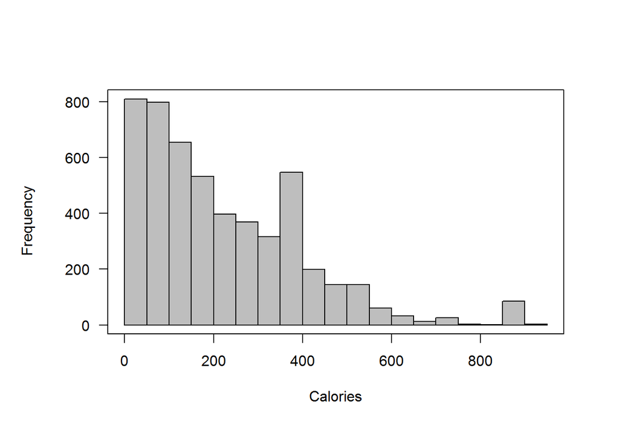

```r
nutrition <- read.csv("nutrition.csv")
par(oma = c(1, 2, 1, 1))  # add an outer margin to plot in
hist(nutrition$Calories, xlab = "Calories", ylab = "", las = 1, main = "",
    col = "grey")
box()
mtext(side = 2, "Frequency", outer = TRUE, line = 0)
```

*Shape*

The overall decreasing height of bins as the calories increase convey that there are lesser and lesser number of food items that have high calorie content.

*Unusual*

The peak at $400$ implies there is a large number of food items that have approx. 400 kilo calories. ( Unsurprisingly, Cereals come in this category.)

The peak after 800 kilo calories, the *Oils* to blame.

**(b)** Create a scatterplot of calories (y-axis) vs protein (x-axis). Make the plot presentable. Do you notice any trends? Do you think that knowing only the protein content of a food, you could make a good prediction of the calories in the food?

**Solution**

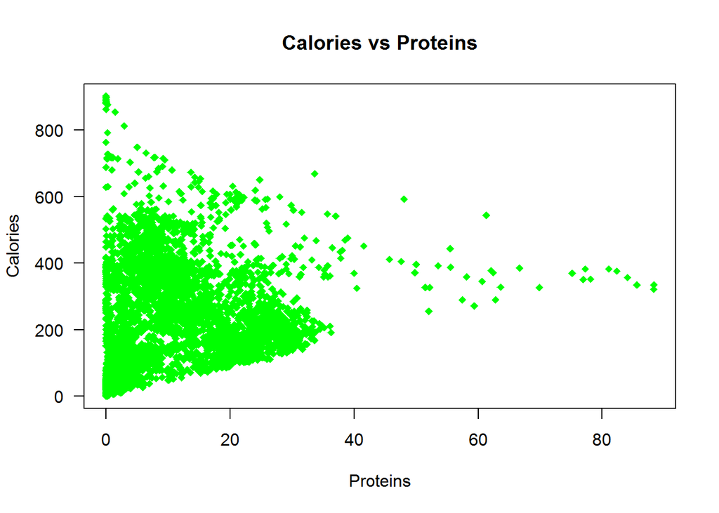

```r
par(las=1)
plot(nutrition$Protein, nutrition$Calories, xlab="Proteins", ylab="Calories",main="Calories vs Proteins",col="green",pch=18)
```

Its hard to see a trend here; and knowing only Protein values, its not a good idea to try and predict Calories.

**(c)** Create a scatterplot of `Calories` (y-axis) vs `4 * Protein + 4 * Carbs + 9 * Fat + 2 * Fiber` (x-axis). Make the plot presentable. You will either need to add a new variable to the data frame, or, use the `I()` function in your formula in the call to `plot()`. If you are at all familiar with nutrition, you may realize that this formula calculates the calorie count based on the protein, carbohydrate, and fat values. You’d expect then that the result here is a straight line. Is it? If not, can you think of any reasons why it is not?

**Solution**

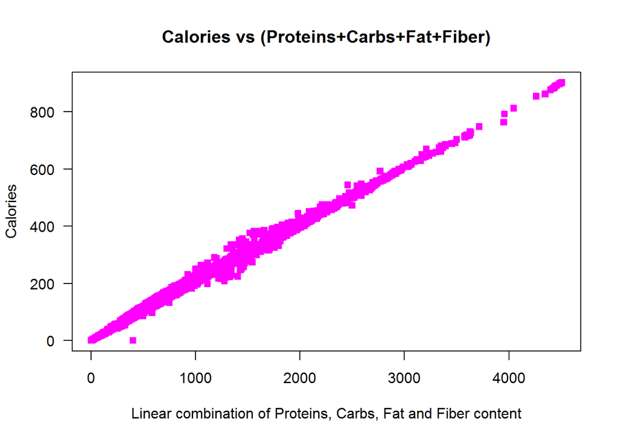

```r
nutrition$temp_x = 4*nutrition$Calories + 4*nutrition$Carbs + 9*nutrition$Fat + 2*nutrition$Fiber
par(las=1)
plot(nutrition$temp_x, nutrition$Calories, xlab="Linear combination of Proteins, Carbs, Fat and Fiber content", ylab="Calories",main="Calories vs (Proteins+Carbs+Fat+Fiber)",col="magenta",pch=15)
```